# Ejemplo de entrega

Analizando los datos de Netflix

Javier Álvarez Liébana https://dadosdelaplace.github.io (Universidad Complutense de Madrid)  
2022-02-01

# Presentación del problema

En est ocasión vamos a usar los **datos de Netflix** proporcionados por **Paula Casado** en [El Arte del Dato](https://elartedeldato.com/blog/como-anadir-una-anotacion-en-ggplot/), página en la que se basará esta visualización: **visualizaremos** el **número de películas y series de instituto** que se han estrenado en **Netflix en cada año**.

Los paquetes que usaremos serán los siguientes

```r
library(tidyverse)
library(lubridate)
library(skimr)
```

## Carga de datos

Los datos provienen originalmente de [Kaggle](https://www.kaggle.com/shivamb/netflix-shows) aunque, como hemos mencionado, usaremos el repositorio de **Paula Casado**, cargando los datos directamente con `read_csv()`.

```r
netflix <-
  read_csv('https://raw.githubusercontent.com/elartedeldato/datasets/main/netflix_titles.csv')
netflix
```

```
# A tibble: 7,787 × 12
   show_id type   title director cast  country date_added release_year
   <chr>   <chr>  <chr> <chr>    <chr> <chr>   <chr>             <dbl>
 1 s1      TV Sh… 3%    <NA>     João… Brazil  August 14…         2020
 2 s2      Movie  7:19  Jorge M… Demi… Mexico  December …         2016
 3 s3      Movie  23:59 Gilbert… Tedd… Singap… December …         2011
 4 s4      Movie  9     Shane A… Elij… United… November …         2009
 5 s5      Movie  21    Robert … Jim … United… January 1…         2008
 6 s6      TV Sh… 46    Serdar … Erda… Turkey  July 1, 2…         2016
 7 s7      Movie  122   Yasir A… Amin… Egypt   June 1, 2…         2019
 8 s8      Movie  187   Kevin R… Samu… United… November …         1997
 9 s9      Movie  706   Shravan… Divy… India   April 1, …         2019
10 s10     Movie  1920  Vikram … Rajn… India   December …         2008
# … with 7,777 more rows, and 4 more variables: rating <chr>,
#   duration <chr>, listed_in <chr>, description <chr>
```

Los datos cargados tienen 7787 registros y 12 variables.

## Breve inspección

Con la función `glimpse()` podemos tener en un vistazo una visión de qué variables tenemos y de que tipo

```r
glimpse(netflix)
```

```
Rows: 7,787
Columns: 12
$ show_id      <chr> "s1", "s2", "s3", "s4", "s5", "s6", "s7", "s8",…
$ type         <chr> "TV Show", "Movie", "Movie", "Movie", "Movie", …
$ title        <chr> "3%", "7:19", "23:59", "9", "21", "46", "122", …
$ director     <chr> NA, "Jorge Michel Grau", "Gilbert Chan", "Shane…
$ cast         <chr> "João Miguel, Bianca Comparato, Michel Gomes, R…
$ country      <chr> "Brazil", "Mexico", "Singapore", "United States…
$ date_added   <chr> "August 14, 2020", "December 23, 2016", "Decemb…
$ release_year <dbl> 2020, 2016, 2011, 2009, 2008, 2016, 2019, 1997,…
$ rating       <chr> "TV-MA", "TV-MA", "R", "PG-13", "PG-13", "TV-MA…
$ duration     <chr> "4 Seasons", "93 min", "78 min", "80 min", "123…
$ listed_in    <chr> "International TV Shows, TV Dramas, TV Sci-Fi &…
$ description  <chr> "In a future where the elite inhabit an island …
```

Con la función `skim()` del paquete `{skimr}` podremos obtener un resumen numérico simple y rápido de nuestras variables

```r
netflix %>% skim()
```

Table 1: Data summary

| Name | Piped data |
| --- | --- |
| Number of rows | 7787 |
| Number of columns | 12 |
| _______________________ |  |
| Column type frequency: |  |
| character | 11 |
| numeric | 1 |
| ________________________ |  |
| Group variables | None |

**Variable type: character**

| skim_variable | n_missing | complete_rate | min | max | empty | n_unique | whitespace |
| --- | --- | --- | --- | --- | --- | --- | --- |
| show_id | 0 | 1.00 | 2 | 5 | 0 | 7787 | 0 |
| type | 0 | 1.00 | 5 | 7 | 0 | 2 | 0 |
| title | 0 | 1.00 | 1 | 104 | 0 | 7787 | 0 |
| director | 2389 | 0.69 | 2 | 208 | 0 | 4049 | 0 |
| cast | 718 | 0.91 | 3 | 771 | 0 | 6831 | 0 |
| country | 507 | 0.93 | 4 | 123 | 0 | 681 | 0 |
| date_added | 10 | 1.00 | 11 | 18 | 0 | 1512 | 0 |
| rating | 7 | 1.00 | 1 | 8 | 0 | 14 | 0 |
| duration | 0 | 1.00 | 5 | 10 | 0 | 216 | 0 |
| listed_in | 0 | 1.00 | 6 | 79 | 0 | 492 | 0 |
| description | 0 | 1.00 | 61 | 248 | 0 | 7769 | 0 |

**Variable type: numeric**

| skim_variable | n_missing | complete_rate | mean | sd | p0 | p25 | p50 | p75 | p100 | hist |
| --- | --- | --- | --- | --- | --- | --- | --- | --- | --- | --- |
| release_year | 0 | 1 | 2013.93 | 8.76 | 1925 | 2013 | 2017 | 2018 | 2021 | ▁▁▁▁▇ |

## Preprocesamiento

### Filtramos películas

Para visualizar antes vamos a filtrar las **películas y series de instituto**, usando la función `str_detect()` (del paquete `{stringr}`), que nos devolverá `TRUE` si detecta en la variable `description` (pasándola a mayúsculas por si acaso) el patrón de texto `"HIGH SCHOOL"`.

```r
netflix_hs <- netflix %>%
  filter(str_detect(toupper(description), "HIGH SCHOOL"))
netflix_hs
```

```
# A tibble: 150 × 12
   show_id type  title  director cast  country date_added release_year
   <chr>   <chr> <chr>  <chr>    <chr> <chr>   <chr>             <dbl>
 1 s8      Movie 187    Kevin R… Samu… United… November …         1997
 2 s32     Movie #Frie… Rako Pr… Adip… Indone… May 21, 2…         2018
 3 s34     Movie #real… Fernand… Nest… United… September…         2017
 4 s47     Movie 1 Cha… Adam De… Lexi… United… July 1, 2…         2014
 5 s48     Movie 1 Mil… Leif Ti… Bill… United… July 7, 2…         2017
 6 s56     Movie 100 T… <NA>     Isab… United… November …         2014
 7 s58     Movie 100% … Jastis … Anis… Indone… January 7…         2020
 8 s148    Movie A Bab… Rachel … Tama… United… October 1…         2020
 9 s251    Movie A Wal… Adam Sh… Mand… United… July 1, 2…         2002
10 s297    Movie Acros… Julien … Sara… Canada  April 1, …         2015
# … with 140 more rows, and 4 more variables: rating <chr>,
#   duration <chr>, listed_in <chr>, description <chr>
```

Podemos hacerlo en más paso, añadiendo una variable extra al conjunto de datos, por ejemplo una variable `hs`, que nos diga `TRUE` si es de instituto y `FALSE` en caso contrario.

```r
netflix <-
  netflix %>%
  mutate(hs = str_detect(toupper(description), "HIGH SCHOOL"))
glimpse(netflix)
```

```
Rows: 7,787
Columns: 13
$ show_id      <chr> "s1", "s2", "s3", "s4", "s5", "s6", "s7", "s8",…
$ type         <chr> "TV Show", "Movie", "Movie", "Movie", "Movie", …
$ title        <chr> "3%", "7:19", "23:59", "9", "21", "46", "122", …
$ director     <chr> NA, "Jorge Michel Grau", "Gilbert Chan", "Shane…
$ cast         <chr> "João Miguel, Bianca Comparato, Michel Gomes, R…
$ country      <chr> "Brazil", "Mexico", "Singapore", "United States…
$ date_added   <chr> "August 14, 2020", "December 23, 2016", "Decemb…
$ release_year <dbl> 2020, 2016, 2011, 2009, 2008, 2016, 2019, 1997,…
$ rating       <chr> "TV-MA", "TV-MA", "R", "PG-13", "PG-13", "TV-MA…
$ duration     <chr> "4 Seasons", "93 min", "78 min", "80 min", "123…
$ listed_in    <chr> "International TV Shows, TV Dramas, TV Sci-Fi &…
$ description  <chr> "In a future where the elite inhabit an island …
$ hs           <lgl> FALSE, FALSE, FALSE, FALSE, FALSE, FALSE, FALSE…
```

Esa variable creada podemos usarla para realizar un conteo de frecuencias, para saber como se reparten nuestros datos respecto a dicha variable `hs`

```r
netflix %>% count(hs)
```

```
# A tibble: 2 × 2
  hs        n
  <lgl> <int>
1 FALSE  7637
2 TRUE    150
```

```r
netflix_filtro <-
  netflix_hs %>% filter(!is.na(date_added))

# Comprobamos que efectivamente no quedan ausentes
netflix_filtro %>% filter(is.na(date_added))
```

```
# A tibble: 0 × 12
# … with 12 variables: show_id <chr>, type <chr>, title <chr>,
#   director <chr>, cast <chr>, country <chr>, date_added <chr>,
#   release_year <dbl>, rating <chr>, duration <chr>,
#   listed_in <chr>, description <chr>
```

### Añadir variable de fecha

Tras dicho filtro vamos a añadir el **año en el que se estrenó**, con la función `year()` de `{lubridate}`, que nos devuelve el año de una fecha concreta. Esa fecha concreta la vamos a construir con `mdy()`.

```r
library(lubridate)
# Ejemplo de funcionamiento
mdy("August 26, 2016")
```

```
[1] "2016-08-26"
```

```r
mdy("January 13, 2015")
```

```
[1] "2015-01-13"
```

```r
netflix_final <-
  netflix_filtro %>%
  mutate(year = year(mdy(date_added)))
glimpse(netflix_final)
```

```
Rows: 150
Columns: 13
$ show_id      <chr> "s8", "s32", "s34", "s47", "s48", "s56", "s58",…
$ type         <chr> "Movie", "Movie", "Movie", "Movie", "Movie", "M…
$ title        <chr> "187", "#FriendButMarried", "#realityhigh", "1 …
$ director     <chr> "Kevin Reynolds", "Rako Prijanto", "Fernando Le…
$ cast         <chr> "Samuel L. Jackson, John Heard, Kelly Rowan, Cl…
$ country      <chr> "United States", "Indonesia", "United States", …
$ date_added   <chr> "November 1, 2019", "May 21, 2020", "September …
$ release_year <dbl> 1997, 2018, 2017, 2014, 2017, 2014, 2020, 2020,…
$ rating       <chr> "R", "TV-G", "TV-14", "TV-PG", "TV-14", "TV-Y",…
$ duration     <chr> "119 min", "102 min", "99 min", "89 min", "105 …
$ listed_in    <chr> "Dramas", "Dramas, International Movies, Romant…
$ description  <chr> "After one of his high school students attacks …
$ year         <dbl> 2019, 2020, 2017, 2017, 2017, 2019, 2021, 2020,…
```

## Conteo y agrupación

Tras la depuración, lo primero que haremos será **agrupar los datos por año** (que tenemos en la nueva variable `year` creada)

```r
netflix_resumen <-
  netflix_final %>%
  group_by(year)
```

Tras ello usaremos dicha variable «invisible» de grupo para contar el número de elementos en cada año.

```r
netflix_resumen <-
  netflix_final %>%
  group_by(year) %>%
  count() %>%
  ungroup()
netflix_resumen
```

```
# A tibble: 9 × 2
   year     n
  <dbl> <int>
1  2011     2
2  2013     1
3  2015     1
4  2016     6
5  2017    18
6  2018    28
7  2019    42
8  2020    46
9  2021     6
```

## Primer diagrama de barras

Con estos datos ya estamos condiciones de poder hacer nuestro diagrama de barras. Realiza un diagrama de barras con el año en el eje X, el número de películas en cada una en el eje Y.

- `x = year`: le indicamos dentro del `aes()` que la coordenada x será mapeada o codificada por la variable `year`
- `y = n`: le indicamos dentro del `aes()` que la coordenada y será mapeada o codificada por la variable `n` (que ha salido del conteo).

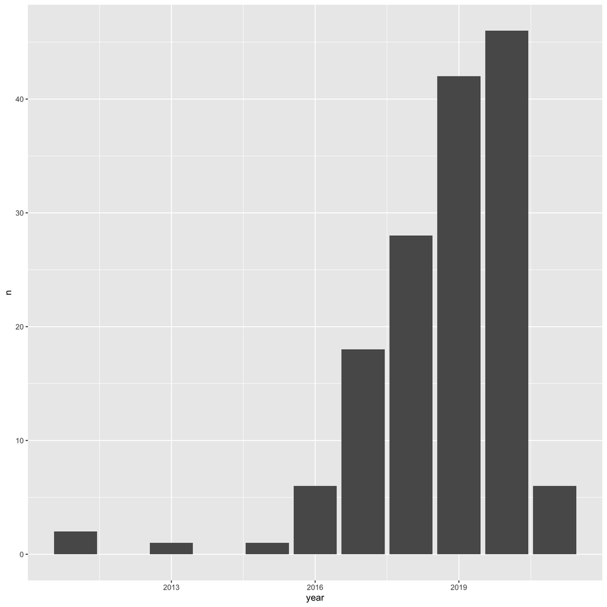

```r
ggplot(netflix_resumen, aes(x = year, y = n)) +
  geom_col()
```

### Color

Vamos a repetir el gráfico indicándole el color del RELLENO de las barras sea rojo (`"red"`), que va codificado en `fill`

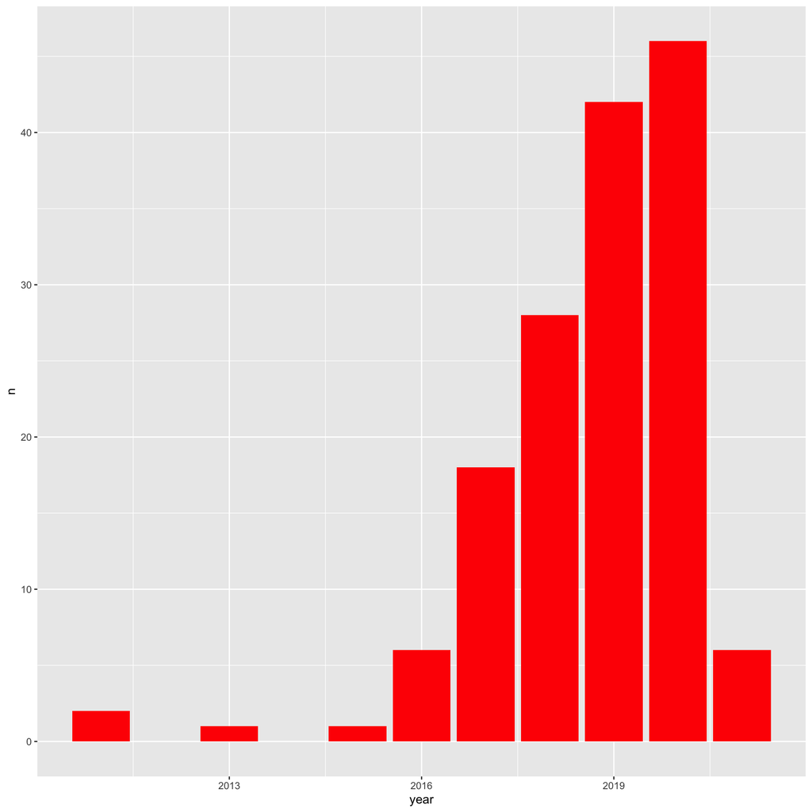

```r
ggplot(netflix_resumen,
       aes(x = year, y = n)) +
  geom_col(fill = "red")
```

### Modificando la escala de los ejes

Si te fijas solo nos ha mostrado algunos años en el eje X, así que le vamos a indicar la **escala concreta** que queremos en dicho eje con `scale_x_continuous()`, usando el argumento `breaks` en el que le indicaremos los valores donde queremos que «corte» el eje X (los corte serán los años guardados en `netflix_resumen$year`)

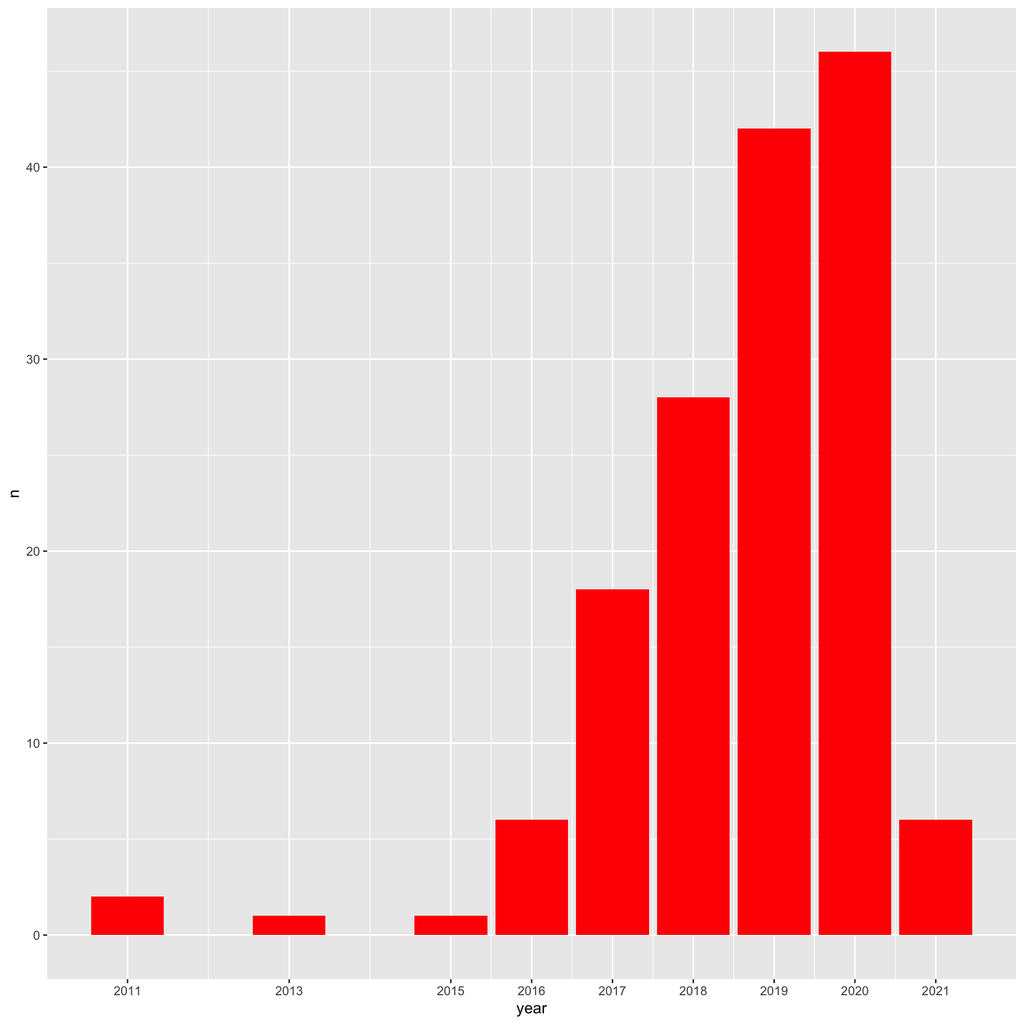

```r
ggplot(netflix_resumen, aes(x = year, y = n)) +
  geom_col(fill = "red") +
  scale_x_continuous(breaks = netflix_resumen$year)
```

### Fechas en los ejes

Cuando uno de los **ejes representa una fecha** podemos indicárselo con `scale_x_date()`, asigándole en `date_breaks` el lapso temporal que queremos en las marcas (por ejemplo, `date_breaks = '1 month'`). Como ejemplo, vamos a visualizar el número de películas y series generales estrenadas en Netflix desde el 1 de julio de 2020.

Antes vamos filtrar el conjunto original `netflix` para quedarnos solo con los registros posteriroes al 1 de julio de 2020, agrupados por fecha

```r
netflix_julio_2022 <-
  netflix %>%
  mutate(date_added = mdy(date_added)) %>%
  filter(date_added > as.Date("2020-07-01")) #<<
```

Con el fichero `netflix_julio_2022`, y haciendo uso `geom_col()` y `scale_x_date(date_breaks = '1 month')`, visualizaremos los datos habiendo personalizado nosotros la escala de fechas del eje X (de mes en mes)

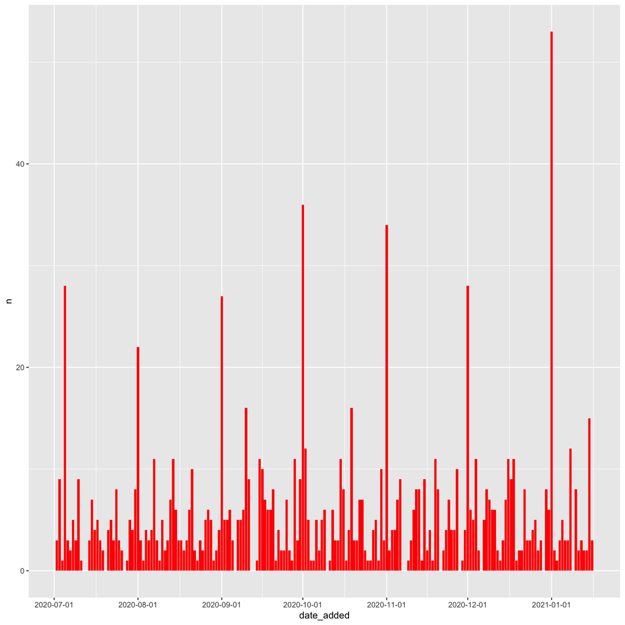

```r
ggplot(netflix_julio_2022 %>%
         group_by(date_added) %>% count(),
       aes(x = date_added, y = n)) +
  geom_col(fill = "red") +
  scale_x_date(date_breaks = '1 month')
```

## Más allá: personalizando tema

Lo primero que vamos a hacer para personalizar es **añadir título, subtítulo y caption**.

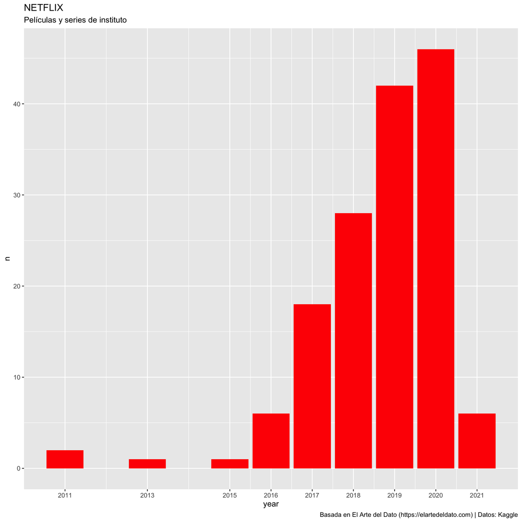

```r
ggplot(netflix_resumen,
       aes(x = year, y = n)) +
  geom_col(fill = "red") +
  scale_x_continuous(breaks = netflix_resumen$year) +
  labs(title = "NETFLIX", #<<
       subtitle = "Películas y series de instituto",
       caption =
         "Basada en El Arte del Dato (https://elartedeldato.com) | Datos: Kaggle")
```

### Fuente propia

En este caso, al ser datos de Netflix, la propia palabara de es una marca por sí misma, y quizás nos interese **usar alguna fuente de Google** para cambiar la fuente por defecto. En este caso vamos a usar la fuente de Netflix, la fuente `Bebas Neue`, y para poder usarla usaremos `font_add_google()`

```r
library(sysfonts)
library(showtext)
font_add_google(family = "Bebas Neue",
                name = "Bebas Neue")
showtext_auto()
```

[figure not shown]

```r
gg <- ggplot(netflix_resumen, aes(x = year, y = n)) +
  geom_col(fill = "red") +
  scale_x_continuous(breaks = netflix_resumen$year) +
  theme_minimal() +
  theme(legend.position = "none",
        plot.title =
          element_text(family = "Bebas Neue",
                       color = "red", size = 80)) +
  labs(title = "NETFLIX",
       subtitle = "Películas y series de instituto",
       caption = "Basada en El Arte del Dato (https://elartedeldato.com) | Datos: Kaggle")
gg
```

### Color de fondo

Tras cambiar la fuente del título vamos a indicarle que el fondo del gráfico sea todo negro.

[figure not shown]

```r
gg <-
  gg +
  theme(panel.background =
          element_rect(fill = "black"),
        plot.background =
          element_rect(fill = "black",
                       color = "black"))
gg
```

### Grid

También vamos a personalizar el grid horizontal (el que marca las alturas del eje y), indicándole color y tamaño.

[figure not shown]

```r
gg <- gg +
  theme(panel.grid.major.y =
          element_line(size = 0.1,
                       color = "white"),
        panel.grid.minor.y = element_blank(),
        panel.grid.major.x = element_blank(),
        panel.grid.minor.x = element_blank())
gg
```

### Fuentes de textos

Vamos a personalizar también la **fuente del subtítulo y caption** y los textos de los ejes.

[figure not shown]

```r
font_add_google(family = "Permanent Marker",
                name = "Permanent Marker")
showtext_auto()
gg <- gg +
  theme(plot.subtitle =
          element_text(family = "Permanent Marker",
                       size = 21, color = "white"),
        plot.caption =
          element_text(family = "Permanent Marker",
                       color = "white", size = 19),
        axis.text =
          element_text(size = 15,
                       family = "Permanent Marker",
                       color = "white"))
gg
```

### Márgenes

Vamos a darle un poco de aire **añadiendo márgenes**

[figure not shown]

```r
gg <- gg +
  theme(plot.margin =
          margin(t = 4, r = 4,
                 b = 4, l = 8, "pt"))
gg
```

### Anotaciones

Por último con `annotate()` podemos añadir anotaciones al gráfico, por ejemplo, escribiendo el mes de enero en la última barra para remarcar que solo llega hasta enero de 2021, con una fina curva como «flecha».

[figure not shown]

```r
gg <- gg  +
  annotate("text", label = "(hasta enero)",
           x = 2021, y = 11,
           hjust = 0.3, vjust = 0,
           family = "Permanent Marker",
           size = 5, color='white', angle = 20) +
  annotate("curve",
           x = 2021, y = 9,
           xend = 2021, yend = 5,
           color = "white")
gg
```